# Risk Factor Analysis

## Outcome Variable

**Outcome Variable:** wast_rec90d

## Predictor Variables

**Intervention Variable:** predfeed6

**Adjustment Set:**

- arm
- sex
- month
- brthmon
- W_mage
- meducyrs
- feducyrs
- hhwealth_quart
- hfoodsec
- W_mhtcm
- vagbrth
- W_gagebrth
- W_birthwt
- W_birthlen
- W_nrooms
- W_nchldlt5
- W_parity
- impfloor
- impsan
- safeh20
- delta_W_mage
- delta_meducyrs
- delta_feducyrs
- delta_hhwealth_quart
- delta_hfoodsec
- delta_W_mhtcm
- delta_vagbrth
- delta_W_gagebrth
- delta_W_birthwt
- delta_W_birthlen
- delta_W_nrooms
- delta_W_nchldlt5
- delta_W_parity
- delta_impfloor
- delta_impsan
- delta_safeh20

## Stratifying Variables

The analysis was stratified on these variable(s):

- agecat
- studyid
- country

## Data Summary

| agecat | studyid | country | predfeed6 | wast_rec90d | n_cell | n |
| --- | --- | --- | --- | --- | --- | --- |
| 0-24 months | ki0047075b-MAL-ED | BANGLADESH | 0 | 0 | 18 | 121 |
| 0-24 months | ki0047075b-MAL-ED | BANGLADESH | 0 | 1 | 35 | 121 |
| 0-24 months | ki0047075b-MAL-ED | BANGLADESH | 1 | 0 | 26 | 121 |
| 0-24 months | ki0047075b-MAL-ED | BANGLADESH | 1 | 1 | 42 | 121 |
| 0-24 months | ki0047075b-MAL-ED | BRAZIL | 0 | 0 | 5 | 23 |
| 0-24 months | ki0047075b-MAL-ED | BRAZIL | 0 | 1 | 17 | 23 |
| 0-24 months | ki0047075b-MAL-ED | BRAZIL | 1 | 0 | 1 | 23 |
| 0-24 months | ki0047075b-MAL-ED | BRAZIL | 1 | 1 | 0 | 23 |
| 0-24 months | ki0047075b-MAL-ED | INDIA | 0 | 0 | 64 | 170 |
| 0-24 months | ki0047075b-MAL-ED | INDIA | 0 | 1 | 97 | 170 |
| 0-24 months | ki0047075b-MAL-ED | INDIA | 1 | 0 | 2 | 170 |
| 0-24 months | ki0047075b-MAL-ED | INDIA | 1 | 1 | 7 | 170 |
| 0-24 months | ki0047075b-MAL-ED | NEPAL | 0 | 0 | 17 | 90 |
| 0-24 months | ki0047075b-MAL-ED | NEPAL | 0 | 1 | 68 | 90 |
| 0-24 months | ki0047075b-MAL-ED | NEPAL | 1 | 0 | 1 | 90 |
| 0-24 months | ki0047075b-MAL-ED | NEPAL | 1 | 1 | 4 | 90 |
| 0-24 months | ki0047075b-MAL-ED | PERU | 0 | 0 | 4 | 29 |
| 0-24 months | ki0047075b-MAL-ED | PERU | 0 | 1 | 19 | 29 |
| 0-24 months | ki0047075b-MAL-ED | PERU | 1 | 0 | 1 | 29 |
| 0-24 months | ki0047075b-MAL-ED | PERU | 1 | 1 | 5 | 29 |
| 0-24 months | ki0047075b-MAL-ED | SOUTH AFRICA | 0 | 0 | 12 | 77 |
| 0-24 months | ki0047075b-MAL-ED | SOUTH AFRICA | 0 | 1 | 65 | 77 |
| 0-24 months | ki0047075b-MAL-ED | SOUTH AFRICA | 1 | 0 | 0 | 77 |
| 0-24 months | ki0047075b-MAL-ED | SOUTH AFRICA | 1 | 1 | 0 | 77 |
| 0-24 months | ki0047075b-MAL-ED | TANZANIA, UNITED REPUBLIC OF | 0 | 0 | 8 | 45 |
| 0-24 months | ki0047075b-MAL-ED | TANZANIA, UNITED REPUBLIC OF | 0 | 1 | 37 | 45 |
| 0-24 months | ki0047075b-MAL-ED | TANZANIA, UNITED REPUBLIC OF | 1 | 0 | 0 | 45 |
| 0-24 months | ki0047075b-MAL-ED | TANZANIA, UNITED REPUBLIC OF | 1 | 1 | 0 | 45 |
| 0-24 months | ki1000109-EE | PAKISTAN | 0 | 0 | 148 | 514 |
| 0-24 months | ki1000109-EE | PAKISTAN | 0 | 1 | 84 | 514 |

[output cut: 126 more lines]

The following strata were considered:

- agecat: 0-24 months, studyid: ki0047075b-MAL-ED, country: BANGLADESH
- agecat: 0-24 months, studyid: ki0047075b-MAL-ED, country: BRAZIL
- agecat: 0-24 months, studyid: ki0047075b-MAL-ED, country: INDIA
- agecat: 0-24 months, studyid: ki0047075b-MAL-ED, country: NEPAL
- agecat: 0-24 months, studyid: ki0047075b-MAL-ED, country: PERU
- agecat: 0-24 months, studyid: ki0047075b-MAL-ED, country: SOUTH AFRICA
- agecat: 0-24 months, studyid: ki0047075b-MAL-ED, country: TANZANIA, UNITED REPUBLIC OF
- agecat: 0-24 months, studyid: ki1000109-EE, country: PAKISTAN
- agecat: 0-24 months, studyid: ki1000304b-SAS-FoodSuppl, country: INDIA
- agecat: 0-24 months, studyid: ki1113344-GMS-Nepal, country: NEPAL
- agecat: 0-24 months, studyid: ki1148112-LCNI-5, country: MALAWI
- agecat: 0-24 months, studyid: kiGH5241-JiVitA-3, country: BANGLADESH
- agecat: 0-24 months, studyid: kiGH5241-JiVitA-4, country: BANGLADESH
- agecat: 0-6 months, studyid: ki0047075b-MAL-ED, country: BANGLADESH
- agecat: 0-6 months, studyid: ki0047075b-MAL-ED, country: BRAZIL
- agecat: 0-6 months, studyid: ki0047075b-MAL-ED, country: INDIA
- agecat: 0-6 months, studyid: ki0047075b-MAL-ED, country: NEPAL
- agecat: 0-6 months, studyid: ki0047075b-MAL-ED, country: PERU
- agecat: 0-6 months, studyid: ki0047075b-MAL-ED, country: SOUTH AFRICA
- agecat: 0-6 months, studyid: ki0047075b-MAL-ED, country: TANZANIA, UNITED REPUBLIC OF
- agecat: 0-6 months, studyid: ki1000109-EE, country: PAKISTAN
- agecat: 0-6 months, studyid: ki1000304b-SAS-FoodSuppl, country: INDIA
- agecat: 0-6 months, studyid: ki1113344-GMS-Nepal, country: NEPAL
- agecat: 0-6 months, studyid: ki1148112-LCNI-5, country: MALAWI
- agecat: 0-6 months, studyid: kiGH5241-JiVitA-3, country: BANGLADESH
- agecat: 0-6 months, studyid: kiGH5241-JiVitA-4, country: BANGLADESH
- agecat: 6-24 months, studyid: ki0047075b-MAL-ED, country: BANGLADESH
- agecat: 6-24 months, studyid: ki0047075b-MAL-ED, country: BRAZIL
- agecat: 6-24 months, studyid: ki0047075b-MAL-ED, country: INDIA
- agecat: 6-24 months, studyid: ki0047075b-MAL-ED, country: NEPAL
- agecat: 6-24 months, studyid: ki0047075b-MAL-ED, country: PERU
- agecat: 6-24 months, studyid: ki0047075b-MAL-ED, country: SOUTH AFRICA
- agecat: 6-24 months, studyid: ki0047075b-MAL-ED, country: TANZANIA, UNITED REPUBLIC OF
- agecat: 6-24 months, studyid: ki1000109-EE, country: PAKISTAN
- agecat: 6-24 months, studyid: ki1000304b-SAS-FoodSuppl, country: INDIA
- agecat: 6-24 months, studyid: ki1113344-GMS-Nepal, country: NEPAL
- agecat: 6-24 months, studyid: ki1148112-LCNI-5, country: MALAWI
- agecat: 6-24 months, studyid: kiGH5241-JiVitA-3, country: BANGLADESH
- agecat: 6-24 months, studyid: kiGH5241-JiVitA-4, country: BANGLADESH

### Dropped Strata

Some strata were dropped due to rare outcomes:

- agecat: 0-24 months, studyid: ki0047075b-MAL-ED, country: BRAZIL
- agecat: 0-24 months, studyid: ki0047075b-MAL-ED, country: INDIA
- agecat: 0-24 months, studyid: ki0047075b-MAL-ED, country: NEPAL
- agecat: 0-24 months, studyid: ki0047075b-MAL-ED, country: PERU
- agecat: 0-24 months, studyid: ki0047075b-MAL-ED, country: SOUTH AFRICA
- agecat: 0-24 months, studyid: ki0047075b-MAL-ED, country: TANZANIA, UNITED REPUBLIC OF
- agecat: 0-24 months, studyid: ki1000304b-SAS-FoodSuppl, country: INDIA
- agecat: 0-24 months, studyid: ki1148112-LCNI-5, country: MALAWI
- agecat: 0-6 months, studyid: ki0047075b-MAL-ED, country: BRAZIL
- agecat: 0-6 months, studyid: ki0047075b-MAL-ED, country: INDIA
- agecat: 0-6 months, studyid: ki0047075b-MAL-ED, country: NEPAL
- agecat: 0-6 months, studyid: ki0047075b-MAL-ED, country: PERU
- agecat: 0-6 months, studyid: ki0047075b-MAL-ED, country: SOUTH AFRICA
- agecat: 0-6 months, studyid: ki0047075b-MAL-ED, country: TANZANIA, UNITED REPUBLIC OF
- agecat: 0-6 months, studyid: ki1000304b-SAS-FoodSuppl, country: INDIA
- agecat: 0-6 months, studyid: ki1148112-LCNI-5, country: MALAWI
- agecat: 6-24 months, studyid: ki0047075b-MAL-ED, country: BRAZIL
- agecat: 6-24 months, studyid: ki0047075b-MAL-ED, country: INDIA
- agecat: 6-24 months, studyid: ki0047075b-MAL-ED, country: NEPAL
- agecat: 6-24 months, studyid: ki0047075b-MAL-ED, country: PERU
- agecat: 6-24 months, studyid: ki0047075b-MAL-ED, country: SOUTH AFRICA
- agecat: 6-24 months, studyid: ki0047075b-MAL-ED, country: TANZANIA, UNITED REPUBLIC OF
- agecat: 6-24 months, studyid: ki1000304b-SAS-FoodSuppl, country: INDIA
- agecat: 6-24 months, studyid: ki1148112-LCNI-5, country: MALAWI
- agecat: 6-24 months, studyid: kiGH5241-JiVitA-3, country: BANGLADESH

## Methods Detail

We’re interested in the causal parameters $E[Y_a]$ for all values of $a \in \mathcal{A}$. These parameters represent the mean outcome if, possibly contrary to fact, we intervened to set all units to have $A=a$. Under the randomization and positivity assumptions, these are identified by the statistical parameters $\psi_a=E_W[E_{Y|A,W}(Y|A=a,W)]$. In addition, we’re interested in the mean of $Y$, $E[Y]$ under no intervention (the observed mean). We will estimate these parameters by using SuperLearner to fit the relevant likelihood factors – $E_{Y|A,W}(Y|A=a,W)$ and $p(A=a|W)$, and then updating our likelihood fit using a joint TMLE.

For unadjusted analyses ($W=\{\}$), initial likelihoods were estimated using Lrnr_glm to estimate the simple $E(Y|A)$ and Lrnr_mean to estimate $p(A)$. For adjusted analyses, a small library containing Lrnr_glmnet, Lrnr_xgboost, and Lrnr_mean was used.

Having estimated these parameters, we will then use the delta method to estimate relative risks and attributable risks relative to a prespecified baseline level of $A$.

# Results Detail

## Results Plots

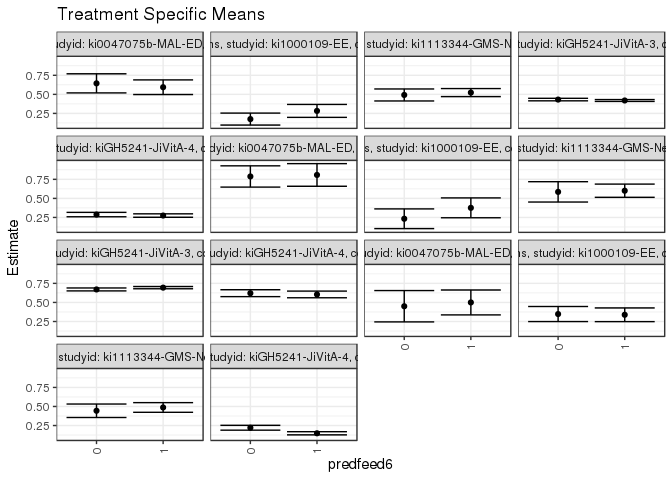

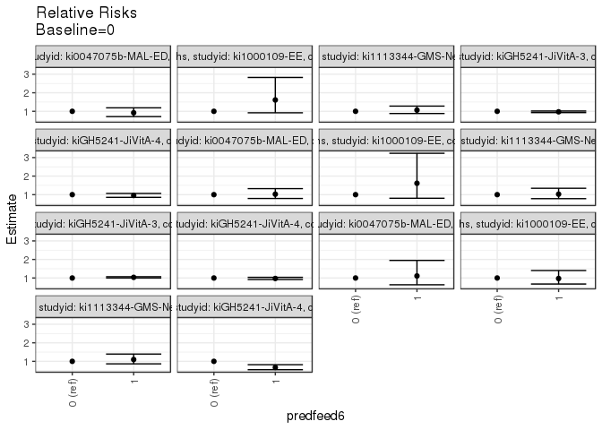

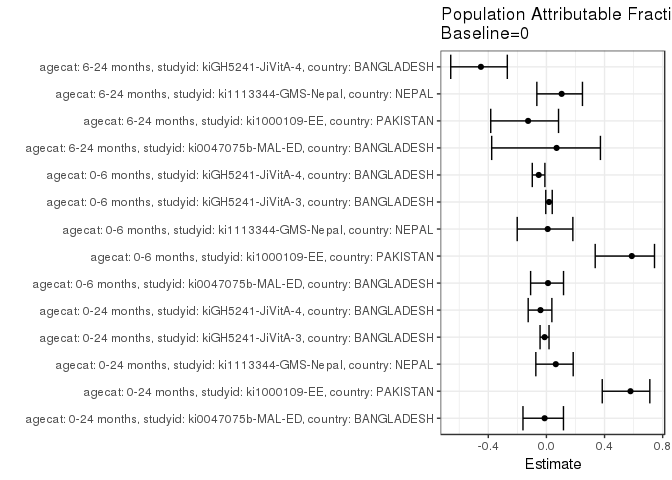

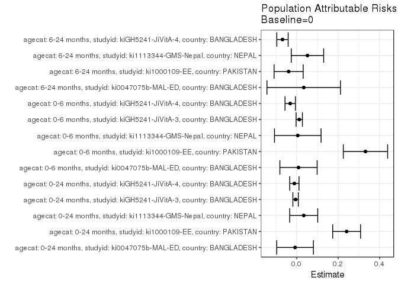

## Results Table

### Parameter: TSM

| agecat | studyid | country | intervention_level | baseline_level | estimate | ci_lower | ci_upper |
| --- | --- | --- | --- | --- | --- | --- | --- |
| 0-24 months | ki0047075b-MAL-ED | BANGLADESH | 0 | NA | 0.6443075 | 0.5188792 | 0.7697357 |
| 0-24 months | ki0047075b-MAL-ED | BANGLADESH | 1 | NA | 0.5936807 | 0.4978327 | 0.6895288 |
| 0-24 months | ki1000109-EE | PAKISTAN | 0 | NA | 0.1754442 | 0.0969914 | 0.2538970 |
| 0-24 months | ki1000109-EE | PAKISTAN | 1 | NA | 0.2830022 | 0.1980979 | 0.3679066 |
| 0-24 months | ki1113344-GMS-Nepal | NEPAL | 0 | NA | 0.4921000 | 0.4133201 | 0.5708798 |
| 0-24 months | ki1113344-GMS-Nepal | NEPAL | 1 | NA | 0.5233076 | 0.4705207 | 0.5760945 |
| 0-24 months | kiGH5241-JiVitA-3 | BANGLADESH | 0 | NA | 0.4315129 | 0.4150494 | 0.4479765 |
| 0-24 months | kiGH5241-JiVitA-3 | BANGLADESH | 1 | NA | 0.4195176 | 0.4073562 | 0.4316790 |
| 0-24 months | kiGH5241-JiVitA-4 | BANGLADESH | 0 | NA | 0.2879768 | 0.2592074 | 0.3167463 |
| 0-24 months | kiGH5241-JiVitA-4 | BANGLADESH | 1 | NA | 0.2750081 | 0.2523166 | 0.2976996 |
| 0-6 months | ki0047075b-MAL-ED | BANGLADESH | 0 | NA | 0.7878788 | 0.6482934 | 0.9274642 |
| 0-6 months | ki0047075b-MAL-ED | BANGLADESH | 1 | NA | 0.8076923 | 0.6590088 | 0.9563759 |
| 0-6 months | ki1000109-EE | PAKISTAN | 0 | NA | 0.2330129 | 0.1037596 | 0.3622663 |
| 0-6 months | ki1000109-EE | PAKISTAN | 1 | NA | 0.3759865 | 0.2455828 | 0.5063903 |
| 0-6 months | ki1113344-GMS-Nepal | NEPAL | 0 | NA | 0.5854544 | 0.4519921 | 0.7189167 |
| 0-6 months | ki1113344-GMS-Nepal | NEPAL | 1 | NA | 0.6007312 | 0.5138454 | 0.6876170 |
| 0-6 months | kiGH5241-JiVitA-3 | BANGLADESH | 0 | NA | 0.6705276 | 0.6512607 | 0.6897945 |
| 0-6 months | kiGH5241-JiVitA-3 | BANGLADESH | 1 | NA | 0.6941814 | 0.6796530 | 0.7087098 |
| 0-6 months | kiGH5241-JiVitA-4 | BANGLADESH | 0 | NA | 0.6213146 | 0.5760523 | 0.6665770 |
| 0-6 months | kiGH5241-JiVitA-4 | BANGLADESH | 1 | NA | 0.6050606 | 0.5614272 | 0.6486941 |
| 6-24 months | ki0047075b-MAL-ED | BANGLADESH | 0 | NA | 0.4500000 | 0.2444054 | 0.6555946 |
| 6-24 months | ki0047075b-MAL-ED | BANGLADESH | 1 | NA | 0.5000000 | 0.3367001 | 0.6632999 |
| 6-24 months | ki1000109-EE | PAKISTAN | 0 | NA | 0.3476312 | 0.2487581 | 0.4465043 |
| 6-24 months | ki1000109-EE | PAKISTAN | 1 | NA | 0.3380963 | 0.2482916 | 0.4279010 |
| 6-24 months | ki1113344-GMS-Nepal | NEPAL | 0 | NA | 0.4439679 | 0.3555697 | 0.5323660 |
| 6-24 months | ki1113344-GMS-Nepal | NEPAL | 1 | NA | 0.4872272 | 0.4238461 | 0.5506083 |
| 6-24 months | kiGH5241-JiVitA-4 | BANGLADESH | 0 | NA | 0.2208227 | 0.1890248 | 0.2526206 |
| 6-24 months | kiGH5241-JiVitA-4 | BANGLADESH | 1 | NA | 0.1482076 | 0.1275246 | 0.1688907 |

### Parameter: E(Y)

| agecat | studyid | country | intervention_level | baseline_level | estimate | ci_lower | ci_upper |
| --- | --- | --- | --- | --- | --- | --- | --- |
| 0-24 months | ki0047075b-MAL-ED | BANGLADESH | NA | NA | 0.6363636 | 0.5494154 | 0.7233119 |
| 0-24 months | ki1000109-EE | PAKISTAN | NA | NA | 0.4163424 | 0.3511349 | 0.4815500 |
| 0-24 months | ki1113344-GMS-Nepal | NEPAL | NA | NA | 0.5260223 | 0.4802445 | 0.5718001 |
| 0-24 months | kiGH5241-JiVitA-3 | BANGLADESH | NA | NA | 0.4262098 | 0.4150208 | 0.4373989 |
| 0-24 months | kiGH5241-JiVitA-4 | BANGLADESH | NA | NA | 0.2766885 | 0.2556490 | 0.2977279 |
| 0-6 months | ki0047075b-MAL-ED | BANGLADESH | NA | NA | 0.7966102 | 0.6946250 | 0.8985954 |
| 0-6 months | ki1000109-EE | PAKISTAN | NA | NA | 0.5648148 | 0.4692893 | 0.6603404 |
| 0-6 months | ki1113344-GMS-Nepal | NEPAL | NA | NA | 0.5906433 | 0.5164645 | 0.6648221 |
| 0-6 months | kiGH5241-JiVitA-3 | BANGLADESH | NA | NA | 0.6828279 | 0.6694976 | 0.6961581 |
| 0-6 months | kiGH5241-JiVitA-4 | BANGLADESH | NA | NA | 0.5900383 | 0.5478064 | 0.6322702 |
| 6-24 months | ki0047075b-MAL-ED | BANGLADESH | NA | NA | 0.4838710 | 0.3544124 | 0.6133295 |
| 6-24 months | ki1000109-EE | PAKISTAN | NA | NA | 0.3087248 | 0.2336906 | 0.3837591 |
| 6-24 months | ki1113344-GMS-Nepal | NEPAL | NA | NA | 0.4959128 | 0.4403572 | 0.5514684 |
| 6-24 months | kiGH5241-JiVitA-4 | BANGLADESH | NA | NA | 0.1522070 | 0.1331665 | 0.1712475 |

### Parameter: RR

| agecat | studyid | country | intervention_level | baseline_level | estimate | ci_lower | ci_upper |
| --- | --- | --- | --- | --- | --- | --- | --- |
| 0-24 months | ki0047075b-MAL-ED | BANGLADESH | 0 | 0 | 1.0000000 | 1.0000000 | 1.0000000 |
| 0-24 months | ki0047075b-MAL-ED | BANGLADESH | 1 | 0 | 0.9214246 | 0.7147258 | 1.1879007 |
| 0-24 months | ki1000109-EE | PAKISTAN | 0 | 0 | 1.0000000 | 1.0000000 | 1.0000000 |
| 0-24 months | ki1000109-EE | PAKISTAN | 1 | 0 | 1.6130609 | 0.9211097 | 2.8248162 |
| 0-24 months | ki1113344-GMS-Nepal | NEPAL | 0 | 0 | 1.0000000 | 1.0000000 | 1.0000000 |
| 0-24 months | ki1113344-GMS-Nepal | NEPAL | 1 | 0 | 1.0634173 | 0.8822571 | 1.2817764 |
| 0-24 months | kiGH5241-JiVitA-3 | BANGLADESH | 0 | 0 | 1.0000000 | 1.0000000 | 1.0000000 |
| 0-24 months | kiGH5241-JiVitA-3 | BANGLADESH | 1 | 0 | 0.9722016 | 0.9311999 | 1.0150087 |
| 0-24 months | kiGH5241-JiVitA-4 | BANGLADESH | 0 | 0 | 1.0000000 | 1.0000000 | 1.0000000 |
| 0-24 months | kiGH5241-JiVitA-4 | BANGLADESH | 1 | 0 | 0.9549660 | 0.8551227 | 1.0664669 |
| 0-6 months | ki0047075b-MAL-ED | BANGLADESH | 0 | 0 | 1.0000000 | 1.0000000 | 1.0000000 |
| 0-6 months | ki0047075b-MAL-ED | BANGLADESH | 1 | 0 | 1.0251479 | 0.7940050 | 1.3235789 |
| 0-6 months | ki1000109-EE | PAKISTAN | 0 | 0 | 1.0000000 | 1.0000000 | 1.0000000 |
| 0-6 months | ki1000109-EE | PAKISTAN | 1 | 0 | 1.6135864 | 0.8059959 | 3.2303653 |
| 0-6 months | ki1113344-GMS-Nepal | NEPAL | 0 | 0 | 1.0000000 | 1.0000000 | 1.0000000 |
| 0-6 months | ki1113344-GMS-Nepal | NEPAL | 1 | 0 | 1.0260939 | 0.7833023 | 1.3441410 |
| 0-6 months | kiGH5241-JiVitA-3 | BANGLADESH | 0 | 0 | 1.0000000 | 1.0000000 | 1.0000000 |
| 0-6 months | kiGH5241-JiVitA-3 | BANGLADESH | 1 | 0 | 1.0352765 | 1.0021315 | 1.0695176 |
| 0-6 months | kiGH5241-JiVitA-4 | BANGLADESH | 0 | 0 | 1.0000000 | 1.0000000 | 1.0000000 |
| 0-6 months | kiGH5241-JiVitA-4 | BANGLADESH | 1 | 0 | 0.9738393 | 0.9165300 | 1.0347321 |
| 6-24 months | ki0047075b-MAL-ED | BANGLADESH | 0 | 0 | 1.0000000 | 1.0000000 | 1.0000000 |
| 6-24 months | ki0047075b-MAL-ED | BANGLADESH | 1 | 0 | 1.1111111 | 0.6335362 | 1.9486934 |
| 6-24 months | ki1000109-EE | PAKISTAN | 0 | 0 | 1.0000000 | 1.0000000 | 1.0000000 |
| 6-24 months | ki1000109-EE | PAKISTAN | 1 | 0 | 0.9725718 | 0.6741398 | 1.4031152 |
| 6-24 months | ki1113344-GMS-Nepal | NEPAL | 0 | 0 | 1.0000000 | 1.0000000 | 1.0000000 |
| 6-24 months | ki1113344-GMS-Nepal | NEPAL | 1 | 0 | 1.0974380 | 0.8651597 | 1.3920785 |
| 6-24 months | kiGH5241-JiVitA-4 | BANGLADESH | 0 | 0 | 1.0000000 | 1.0000000 | 1.0000000 |
| 6-24 months | kiGH5241-JiVitA-4 | BANGLADESH | 1 | 0 | 0.6711613 | 0.5492153 | 0.8201838 |

### Parameter: PAR

| agecat | studyid | country | intervention_level | baseline_level | estimate | ci_lower | ci_upper |
| --- | --- | --- | --- | --- | --- | --- | --- |
| 0-24 months | ki0047075b-MAL-ED | BANGLADESH | 0 | NA | -0.0079438 | -0.0963420 | 0.0804543 |
| 0-24 months | ki1000109-EE | PAKISTAN | 0 | NA | 0.2408982 | 0.1736443 | 0.3081521 |
| 0-24 months | ki1113344-GMS-Nepal | NEPAL | 0 | NA | 0.0339223 | -0.0336224 | 0.1014670 |
| 0-24 months | kiGH5241-JiVitA-3 | BANGLADESH | 0 | NA | -0.0053031 | -0.0184449 | 0.0078387 |
| 0-24 months | kiGH5241-JiVitA-4 | BANGLADESH | 0 | NA | -0.0112884 | -0.0336916 | 0.0111148 |
| 0-6 months | ki0047075b-MAL-ED | BANGLADESH | 0 | NA | 0.0087314 | -0.0812361 | 0.0986989 |
| 0-6 months | ki1000109-EE | PAKISTAN | 0 | NA | 0.3318019 | 0.2248457 | 0.4387581 |
| 0-6 months | ki1113344-GMS-Nepal | NEPAL | 0 | NA | 0.0051889 | -0.1072028 | 0.1175805 |
| 0-6 months | kiGH5241-JiVitA-3 | BANGLADESH | 0 | NA | 0.0123003 | -0.0029225 | 0.0275231 |
| 0-6 months | kiGH5241-JiVitA-4 | BANGLADESH | 0 | NA | -0.0312763 | -0.0563854 | -0.0061673 |
| 6-24 months | ki0047075b-MAL-ED | BANGLADESH | 0 | NA | 0.0338710 | -0.1435771 | 0.2113190 |
| 6-24 months | ki1000109-EE | PAKISTAN | 0 | NA | -0.0389064 | -0.1091023 | 0.0312896 |
| 6-24 months | ki1113344-GMS-Nepal | NEPAL | 0 | NA | 0.0519449 | -0.0262126 | 0.1301025 |
| 6-24 months | kiGH5241-JiVitA-4 | BANGLADESH | 0 | NA | -0.0686157 | -0.0960496 | -0.0411818 |

### Parameter: PAF

| agecat | studyid | country | intervention_level | baseline_level | estimate | ci_lower | ci_upper |
| --- | --- | --- | --- | --- | --- | --- | --- |
| 0-24 months | ki0047075b-MAL-ED | BANGLADESH | 0 | NA | -0.0124831 | -0.1613414 | 0.1172948 |
| 0-24 months | ki1000109-EE | PAKISTAN | 0 | NA | 0.5786059 | 0.3841771 | 0.7116493 |
| 0-24 months | ki1113344-GMS-Nepal | NEPAL | 0 | NA | 0.0644884 | -0.0728182 | 0.1842216 |
| 0-24 months | kiGH5241-JiVitA-3 | BANGLADESH | 0 | NA | -0.0124424 | -0.0437833 | 0.0179574 |
| 0-24 months | kiGH5241-JiVitA-4 | BANGLADESH | 0 | NA | -0.0407982 | -0.1254787 | 0.0375110 |
| 0-6 months | ki0047075b-MAL-ED | BANGLADESH | 0 | NA | 0.0109607 | -0.1087726 | 0.1177643 |
| 0-6 months | ki1000109-EE | PAKISTAN | 0 | NA | 0.5874525 | 0.3356949 | 0.7437993 |
| 0-6 months | ki1113344-GMS-Nepal | NEPAL | 0 | NA | 0.0087851 | -0.2009719 | 0.1819067 |
| 0-6 months | kiGH5241-JiVitA-3 | BANGLADESH | 0 | NA | 0.0180138 | -0.0045040 | 0.0400267 |
| 0-6 months | kiGH5241-JiVitA-4 | BANGLADESH | 0 | NA | -0.0530073 | -0.0972827 | -0.0105184 |
| 6-24 months | ki0047075b-MAL-ED | BANGLADESH | 0 | NA | 0.0700000 | -0.3766411 | 0.3717317 |
| 6-24 months | ki1000109-EE | PAKISTAN | 0 | NA | -0.1260228 | -0.3832461 | 0.0833683 |
| 6-24 months | ki1113344-GMS-Nepal | NEPAL | 0 | NA | 0.1047461 | -0.0658705 | 0.2480517 |
| 6-24 months | kiGH5241-JiVitA-4 | BANGLADESH | 0 | NA | -0.4508050 | -0.6585383 | -0.2690906 |